# Weight lifting - Classifying the quality of the exercise via sensor data

AM

26 July 2022

## Introduction

In order to quantify how well an exercise is performed, data were acquired via accelerometers on belt, forearm, arm, and dumbell of 6 participants, while performing barbell lifts correctly and incorrectly in 5 different ways, identified in the data as variable classe (source: http://groupware.les.inf.puc-rio.br/har). The aim is to enable recognition of the quality of the activity via a classification algorithm. Via exploratory data analysis, the variables to perform classification were individuated, and further reduced in number through correlation analysis. Tests with simpler classification models revealed poor performance, after which random forest was selected. The model yield OOB estimate of error less than 1%, with average accuracy over 99%, both estimated by using cross validation.

The final prediction on 20 test samples yields 100% accuracy, if the correlation between window number and activity class detected in the training data holds for the test data as well.

## EDA and tidying

### Missing values

The downloaded data have 160 columns, with 19622 samples for the training data and 20 for the testing. For each sample, the classe variable identifies the mode of execution, 152 variables are measurements records (38 per sensor), and the remaining 7 are identifiers for the user, time and exercise window. The latter variables will therefore be removed. Furthermore, an invalid entry check in the train data reveals 67 measurements columns with 97.93% missing values. A similar check on the test data shows that only 60 columns are not empty. Hence, the empty test columns will be removed from both datasets, obtaining datasets with 53 columns.

### Multicollinearity

Furthermore, plotting several variables against classe, shows differences between classes.

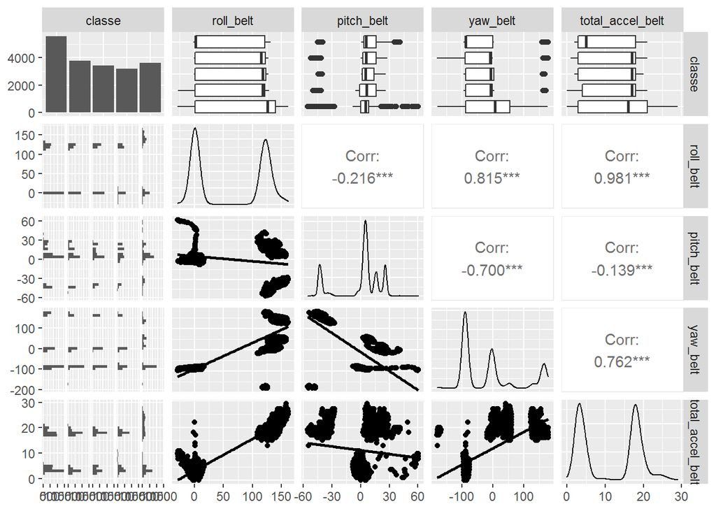

**Fig.1**: *Relationship between classe and several variables.*

## Model

The model is tested via cross-validation, given the limited number of samples in the test dataset and the requirements for the present assignment. For computational speed reasons, 5-fold cross validation will be performed, together with parallelization when necessary. The performance of the different methods is monitored via the average cross-validation accuracy.

**Table 1**: *Confusion matrix for regression with Recursive Partitioning*.

[output not shown]

**Table 2**: *Confusion matrix for regression with Linear Discriminant Analysis*.

[output not shown]

Use of simpler methods such as Recursive Partitioning (*rpart*) and Linear Discriminant Analysis (*LDA*) yields low accuracy (50.38% and 64.31% respectively), suggesting the need for a more computationally requiring method.

**Table 3**: *Confusion matrix for regression with Gradient Boosting Machine*.

[output not shown]

**Table 4**: *Confusion matrix for regression with Random Forest*.

| Observed | Observed A | Observed B | Observed C | Observed D | Observed E |
| --- | --- | --- | --- | --- | --- |
| **Predicted - rf** |  |  |  |  |  |
| A | 5580 | 0 | 0 | 0 | 0 |
| B | 0 | 3797 | 0 | 0 | 0 |
| C | 0 | 0 | 3422 | 0 | 0 |
| D | 0 | 0 | 0 | 3216 | 0 |
| E | 0 | 0 | 0 | 0 | 3607 |

Employing a Gradient Boosting Machine (*gbm*) gives an accuracy of 95.37%, which is quite an improvement, while Random Forest provides average accuracy from cross validation of 99.32%, which shows that model obtained with random forest method is satisfactory. For the latter, instead of the Out Of Sample error, the Out Of Bag error is estimated, yielding a value of 0.54%.

## Prediction

The predicted classe for the samples in the test dataset is the following:

B, A, B, A, A, E, D, B, A, A, B, C, B, A, E, E, A, B, B, B

If actual num_window in test data has the same correspondence to classe as in the training dataset, there is a 100% correct prediction.

## Code

```r
library(knitr)
opts_chunk$set(echo = FALSE, results = "as is", message = FALSE, warning = FALSE)
## Download data
pml_training<- read.csv("https://d396qusza40orc.cloudfront.net/predmachlearn/pml-training.csv")
pml_testing<- read.csv("https://d396qusza40orc.cloudfront.net/predmachlearn/pml-testing.csv")
# EDA and tidying
dimTr <- dim(pml_training)
dimTe <- dim(pml_testing)
num_classe <- unique(pml_training$classe) # 5 classes
meas <- length(grep("belt|arm|dumb", names(pml_training), ignore.case = TRUE)) # 38 measurements columns per sensor
# Check NAs in train
na_count <- sapply(pml_training,function(x) sum(is.na(x)))
num_nacount <- unique(na_count) # [1]     0 19216
prop_missing <- max(na_count)/dim(pml_training)[1] # for many columns 97% of the values are missing
cols_missing <- sum(na_count == max(na_count)) # 67 columns with 97% missing vals: we will be left with 93 variables
# Check NAs in test
na_count_tst <- sapply(pml_testing,function(x) sum(is.na(x)))
num_na_tst <- unique(na_count_tst) # 0 20
notna_names <- names(na_count_tst[na_count_tst != max(na_count_tst)]) # cols with values
not_NA_cols <- length(notna_names) # cols with values
# Remove columns: first the empty test columns, then the identifier columns
new_testing <- pml_testing[, names(pml_testing) %in% c(notna_names,"classe")]
new_training <- pml_training[, names(pml_training) %in% c(notna_names,"classe")]
new_training <- new_training[,c(8:60)]
new_testing <- new_testing[,c(8:60)]
num_cols <- dim(new_training)[2]
# check for multicollinearity
library(caret)
cor_mat = cor(new_training[-53])

hc = findCorrelation(cor_mat, cutoff = 0.8)
hc = sort(hc)
reduced_train = new_training[,-c(hc)]
reduced_test = new_testing[,-c(hc)]
red_cols <- dim(reduced_train)[2]
reduced_train$classe <- as.factor(reduced_train$classe)
# EDA plot
library(GGally); library(ggplot2)
ggpairs(new_training[,c(53,1:4)], lower = list(continuous = "smooth"))
# rpart
set.seed(11111)
library(caret)
cv_rpart_Fit <- train(classe ~.,data = reduced_train, method="rpart",
                      trControl = trainControl(method="cv",number=5))
CM_rpart <- confusionMatrix.train(cv_rpart_Fit)
Acc_rpart <- round(sum(diag(CM_rpart$table)),2)
# lda
fit_LDA <- train(classe ~., method = "lda", data = reduced_train, trControl = trainControl(method="cv",number=5))
CM_LDA <- confusionMatrix.train(fit_LDA)
Acc_lda <- round(sum(diag(CM_LDA$table)),2)
library(kableExtra)
CM_count_rpart <- confusionMatrix(reduced_train$classe, predict(cv_rpart_Fit, newdata = reduced_train))
CM_count_LDA <- confusionMatrix(reduced_train$classe, predict(fit_LDA, newdata = reduced_train))
rpart_k <- knitr::kable(CM_count_rpart$table, caption =
        "**Table 1**: *Confusion matrix for regression with Recursive Partitioning*.") %>%
        kable_styling(full_width = F, position = 'float_left') %>%
        add_header_above(c("Observed" = ncol(CM_count_rpart$table)+1)) %>%
        group_rows("Predicted - rpart",1,5) %>% column_spec(1, bold = TRUE, width = "7em")
LDA_k <- knitr::kable(CM_count_LDA$table, caption =
        "**Table 2**: *Confusion matrix for regression with Linear Discriminant Analysis*.") %>%
        kable_styling(full_width = F, position = 'left') %>%
        add_header_above(c("Observed" = ncol(CM_count_LDA$table)+1)) %>%
        group_rows("Predicted - lda",1,5) %>% column_spec(1, bold = TRUE, width = "7em")
rpart_k
LDA_k
# gbm booster predictor
library(gbm)
fit_gbm <- train(classe ~., method = "gbm", data = reduced_train, verbose = FALSE, trControl = trainControl(method="cv",number=5))
CM_B <- confusionMatrix.train(fit_gbm)
Acc_gbm <- round(sum(diag(CM_B$table)),2)
library(parallel)
# Calculate the number of cores for parallel computation
no_cores <- detectCores() - 1
library(doParallel)
# create the cluster for caret to use
cl <- makePSOCKcluster(no_cores)
registerDoParallel(cl)
library(randomForest)
set.seed(11111)
cv_rf_Fit <- train(classe ~.,data = reduced_train, method="rf",
                   trControl = trainControl(method="cv",number=5), allowParallel = TRUE)
stopCluster(cl)
registerDoSEQ()
# Calculate accuracy
CM_rf <- confusionMatrix.train(cv_rf_Fit)
Acc_rf <- round(sum(diag(CM_rf$table)),2)
# Calculate OOB error
CM_count_rf <- cv_rf_Fit$finalModel$confusion
OOB_rf <- round((sum(CM_count_rf)-sum(diag(CM_count_rf)))/sum(CM_count_rf)*100,2)
CM_count_gbm <- confusionMatrix(reduced_train$classe, predict(fit_gbm, newdata = reduced_train))
CM_count2_rf <- confusionMatrix(reduced_train$classe, predict(cv_rf_Fit, newdata = reduced_train))
gbm_k <- knitr::kable(CM_count_gbm$table, caption =
        "**Table 3**: *Confusion matrix for regression with Gradient Boosting Machine*.") %>%
        kable_styling(full_width = F, position = 'float_left') %>%
        add_header_above(c("Observed" = ncol(CM_count_rpart$table)+1)) %>%
        group_rows("Predicted - gbm",1,5) %>% column_spec(1, bold = TRUE, width = "7em")
rf_k <- knitr::kable(CM_count2_rf$table, caption =
        "**Table 4**: *Confusion matrix for regression with Random Forest*.") %>%
        kable_styling(full_width = F, position = 'left') %>%
        add_header_above(c("Observed" = ncol(CM_count_LDA$table)+1)) %>%
        group_rows("Predicted - rf",1,5) %>% column_spec(1, bold = TRUE, width = "7em")
gbm_k
rf_k
predictions <- predict(cv_rf_Fit,newdata = reduced_test)
```